# MFC Kick-Off Camp

Introduction to change point detection

Euan McGonigle

## Session Plan

### First part:

- Learn about what change point detection is.
- Learn what the common change point methods are.
- Learn about some software we can use.

### Second part:

- Write code and use software to try out change point algorithms.
- Compare methods and see the pros/cons.
- Perform change point analysis on some environmental data sets.

All materials for today are available at: github.com/EuanMcGonigle/IntroToCPD.

## Software we’ll use

I’ll be using R for the session, but if you are more comfortable then please use Python: both have everything we need for what we’ll cover today.

If you want to use R, you’ll need:

- `changepoint`
- `mosum`
- `EnvCpt`

If you want to use Python, you’ll need:

- `ruptures`
- `mosum`

## Introduction

- Time series are now recorded in higher volumes over longer periods.
- Often, dynamics of time series are assumed stationary – unrealistic!
- Instead, we can develop nonstationary time series models.
- Could be with respect to mean level, spectral density, correlation, ...
- Examples: climatology, finance, neuroscience, ...
- 1 approach: piecewise stationarity via change point detection.

[figure not shown]

[figure not shown]

[figure not shown]

## Introduction

- We might want to take a change point approach to model things like:
  1. air quality,
  2. frequencies of earthquakes,
  3. global surface temperatures,
  4. sentiment of text data like tweets.
- We’ll focus on some common time series models to illustrate key ideas, but these techniques can be readily adapted to other more complicated models.

## Change point detection (CPD)

Change points: abrupt changes in the statistical properties of the time series. Also known as:

- data segmentation,
- break points,
- structural breaks,
- data shift/drift, ...

We’ll look at some of the most well-studied settings, and see how some simple ideas can be used to build powerful CPD algorithms.

## Change point detection (CPD)

Change points could occur in any properties of the data we want to model, such as the mean, dependence, and trend:

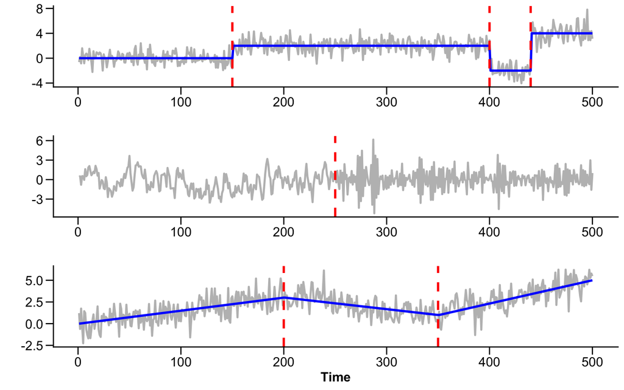

## More complicated models

How many change points below? And where?

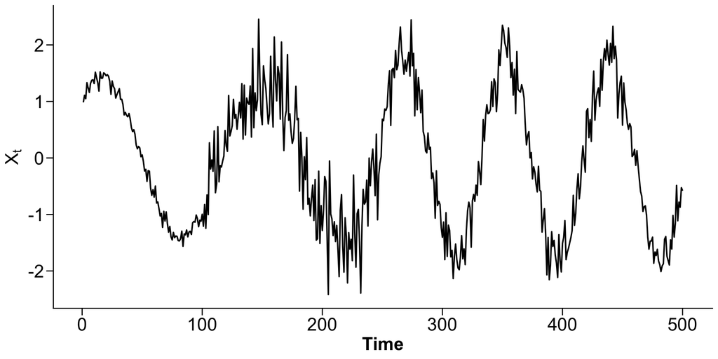

## More complicated models

How many change points below? And where?

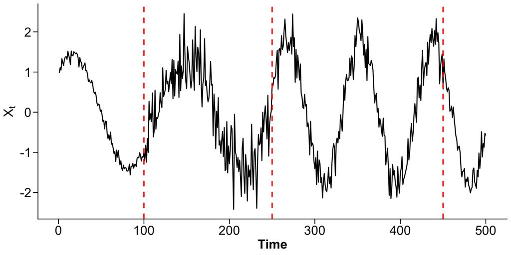

## More complicated models

How many change points below? And where?

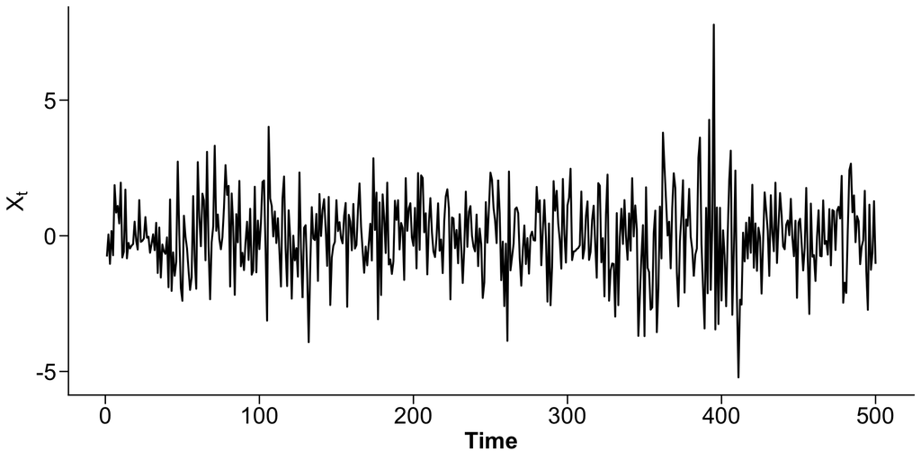

## CPD: the goals

A time series is split into stationary segments defined by the change points. We want to:

1. **Test:** Have changes occurred? If so, how many?
2. **Localise:** Where have the changes happened?
3. **Theoretically justify:** Statistical guarantee on number of changes and accuracy of estimated locations.
4. **Analyse post-segmentation:** Estimate parameters, quantify uncertainty, forecasting, causality?

## Example application: global surface temperature anomalies

Yearly global mean surface temperature (land and ocean) anomalies relative to the 1951-1980 baseline (NASA GISTEMP):

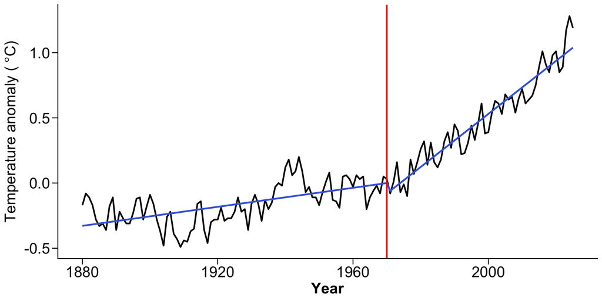

## Example application: earthquake occurrences

Monthly number of earthquakes in the Groningen gas field:

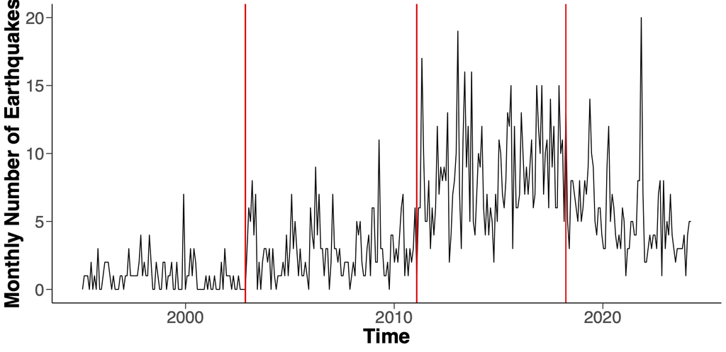

## Why CPD?

- The simplest possible nonstationary model.
- Very interpretable.
- Tends to lead to computationally tractable and exact solutions.
- Often we can tie change points to physical phenomena e.g. stock market crash, policy interventions, human-made emissions.
- Data-driven, “agnostic" intervention analysis.

## Simple model – change in mean

Let’s look at the canonical change in mean problem:
$$X_{t} = f_{t} + \varepsilon_{t} = \sum_{j=0}^{q} \mu_{j} \cdot \mathbb{I}\{\theta_{j}+1 \leq t \leq \theta_{j+1}\} + \varepsilon_{t}, \quad t = 1, \ldots, n.$$

- $f_t$ is the signal – piecewise constant mean function.
- $f_t$ has jumps at the $q$ change points $\theta_1, \ldots , \theta_q$. ($\theta_0 = 0, \theta_{q+1} = n)$.
- $\varepsilon_t$ is a zero-mean noise term.

Note: for a general setting:
$$X_t = \sum_{j=0}^{q} X^{(j)}_t \cdot \mathbb{I}\{\theta_{j}+1 \leq t \leq \theta_{j+1}\},$$
where distributions of $X^{(j)}$ and $X^{(j+1)}$ differ somehow.

## Aside – online vs offline

Two main settings for CPD are **offline** and **online**.

**Online**:

- Processes the data as it arrives, or in batches.
- Main aim is to quickly detect new changes.
- Applications include process control monitoring, fault detection.

**Offline**:

- Processes all the data in one go, after it has all been collected.
- Main aim is accurate detection of changes.
- Applications include genome analysis.

## Aside – online vs offline

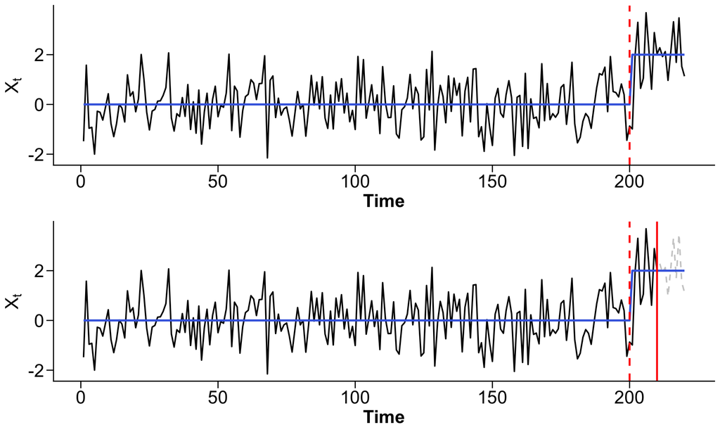

## Simple model – change in mean

What do we want to do?

- Estimate the number of change points $q$.
- Estimate the change point locations $\theta_1, \ldots , \theta_q$.

How do we do that?

- Many approaches, 2 of which are:
  - Localised testing using a test statistic.
  - Global minimisation using a cost function based on data fit.

## Localised testing

- Scan data for candidate change point estimators.
- Typically involve computing a test statistic of the form $\widehat{\sigma}_{s, e}^{-1} \vert {T}_{s, k, e} \vert$, where
  $${T}_{s, k, e} = \sqrt{ \frac{(k-s)(e-k)}{e-s}} \left( \frac{1}{k-s} \sum_{t=s+1}^{k} X_{t} - \frac{1}{e-k} \sum_{t=k+1}^{e} X_{t} \right) ,$$
  and $\widehat{\sigma}_{s, e}$ is an estimator of $\sigma_{s,e}$, a measure of variability of $\{X_t \}_{t=s}^e$.
- Compute ${T}_{s, k, e}$ for all $k$ over a range of intervals to find the most likely change point locations.
- Often compare $\widehat{\sigma}_{s, e}^{-1} \vert {T}_{s, k, e} \vert$ to a threshold $D$ to test for changes.

## CUSUM approaches: idea

- Simplest example is the cumulative sum (CUSUM):
  $${T}_{0, k, n} = \sqrt{ \frac{k(n-k)}{n}} \left( \frac{1}{k} \sum_{t=1}^{k} X_{t} - \frac{1}{n-k} \sum_{t=k+1}^{n} X_{t} \right) .$$
  - To find a single change $\theta_1$ we compute ${T}_{0, k, n}$ for all $1 \leq k \leq n-1$, and set
    $$\widehat{\theta}_1 = \mathop{\mathrm{arg\,max}}_{1 \leq k \leq n-1} \left| {T}_{0, k, n} \right|$$
    to be the change point estimator.
- We declare $\widehat{\theta}_1$ as a change if $\hat{\sigma}^{-1} | {T}_{0, \widehat{\theta}_1 , n} | > D$.
- Many CPD methods start with the CUSUM as the basic idea, but use fancier ideas.

## CUSUM approaches: single change

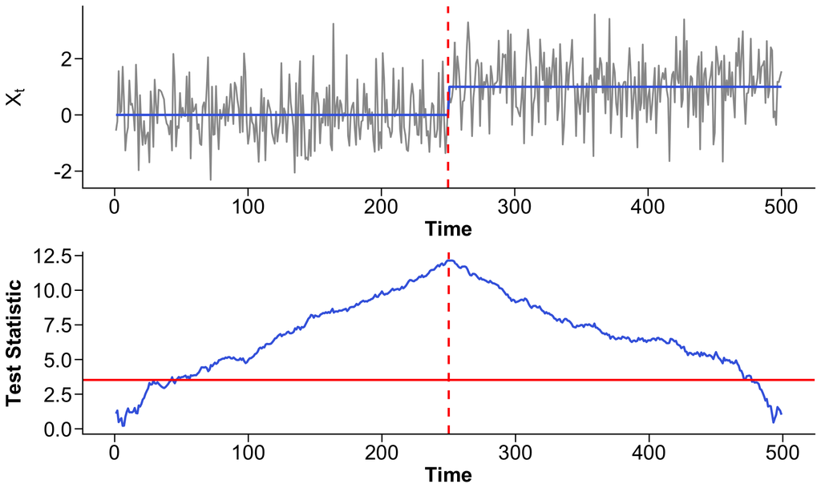

## CUSUM approaches: multiple changes

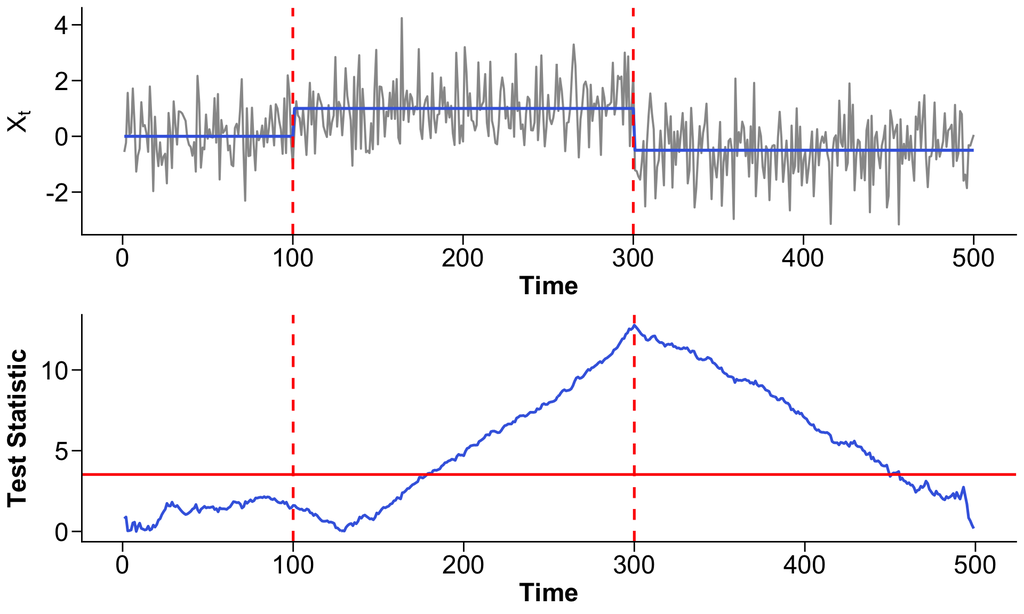

## CUSUM approaches: extensions

- It’s easy to extend the global CUSUM to look for multiple change points.
- In Binary Segmentation (BS), after calculating $\widehat{\theta}_1$, we then perform 2 CUSUMs on the intervals $[1, \widehat{\theta}_1]$ and $[\widehat{\theta}_1 +1 , n]$, and rinse and repeat.
- Wild binary segmentation extends this by using BS on a set of randomly generated intervals.
- Many other state-of-the-art methods devise sophisticated “interval generation” techniques, upon which CUSUMs are performed.

## CUSUM approaches: smart interval generation

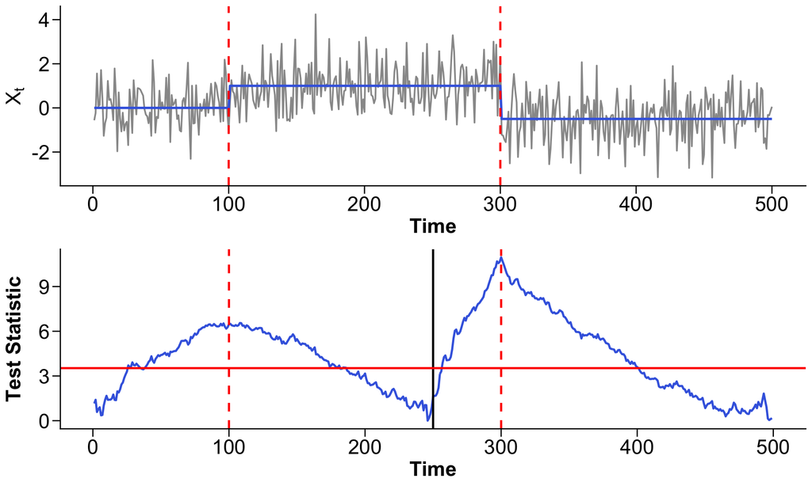

## MOSUM approaches

There are many other CPD methods that use localised testing.

- The **MOSUM** approach uses moving windows of size $G$ to the left and right of candidate change $k$.
- This allows it to simultaneously find multiple changes.
- For window size $G$, the MOSUM detector $T_{G}(k)$ is given by
  $$T_{G}(k) = {T}_{k-G, k, k+G} = \frac{1 }{\sqrt{2G}}\left( \sum_{t=k+1}^{k+G} X_{t} - \sum_{t=k-G+1}^{k} X_{t} \right)$$
  for $k = G, \ldots, n-G$.
- Changes declared as all local maximisers with $\widehat \sigma^{-1} \vert T_{G}(k) \vert > D.$

## MOSUM approaches: multiple change points

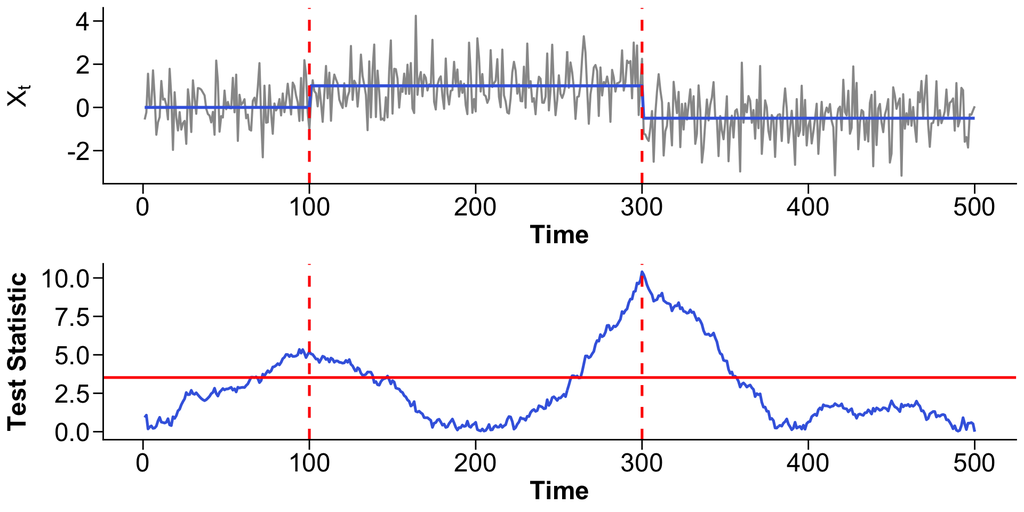

## MOSUM approaches: extensions

- Again, this is a simple idea that can be extended into more sophisticated algorithms.
- Uncertainty quantification on change locations via bootstrap.
- Instead of using $G$ data points on each side of the window, can use asymmetric sizes.
- Can easily be generalised to multivariate data and other types of change.
- A multiscale version of MOSUM using multiple bandwidths helps to detect changes of different sizes and different segment lengths:

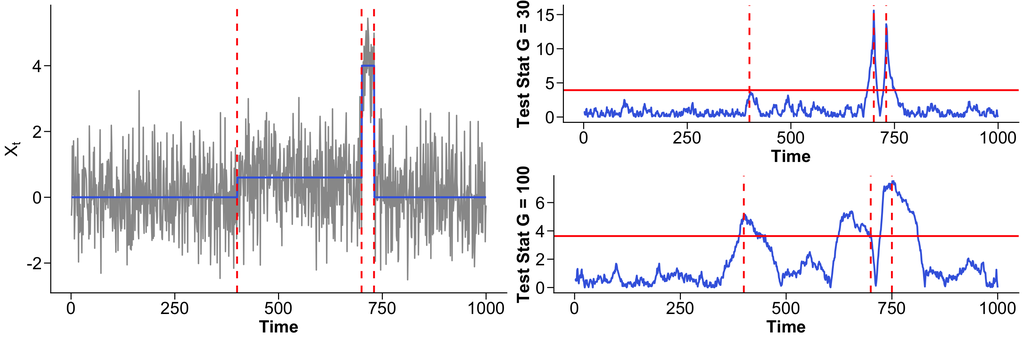

## Global cost function approaches

Another common approach are global methods using cost functions.

- A cost function $C (X_{s:e})$ measures how well (badly) the model fits the data on the segment $\{ X_t\}_{t=s}^e$.
- For 1 change point, we can measure the cost of fitting a change point at time $k$ as $C (X_{1:k})+ C (X_{(k+1):n})$.
- For finding $q$ change points, we can minimise the equation
  $$\sum_{j= 1}^{q+1} C (X_{(\theta_{j-1} +1):\theta_j} ) + f(q),$$
  where $f(q)$ is a penalty to avoid overfitting.
- Twice the negative log likelihood is a commonly used cost function.

## Cost function approaches: PELT

- Trying to calculate this minimum exhaustively is not feasible.
- Thankfully it can be calculated recursively: the minimal cost for $X_{1:s}$ can be expressed in terms of that of $X_{1:t}$ for $t < s$.
- This is still complexity ${O}(n^2)$: the Pruned Exact Linear Time (PELT) method improves this to expected complexity ${O}(n)$.
- Achieves this by pruning the set of possible change point locations in a clever way, using properties of the cost function.
- For change in mean, equivalent to least-squares estimation.

## Nonparametric approaches

What if we’re not sure what type of parameters/model we want to pick?

We can miss changes if we don’t know what we’re looking for, or falsely detect changes, if we assume the wrong model:

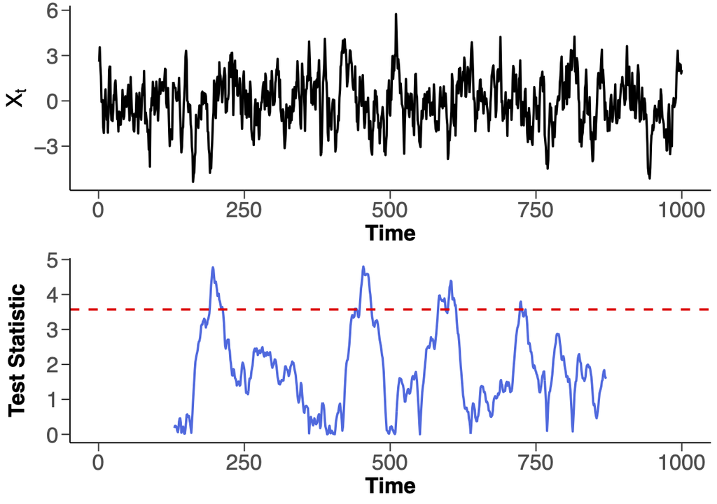

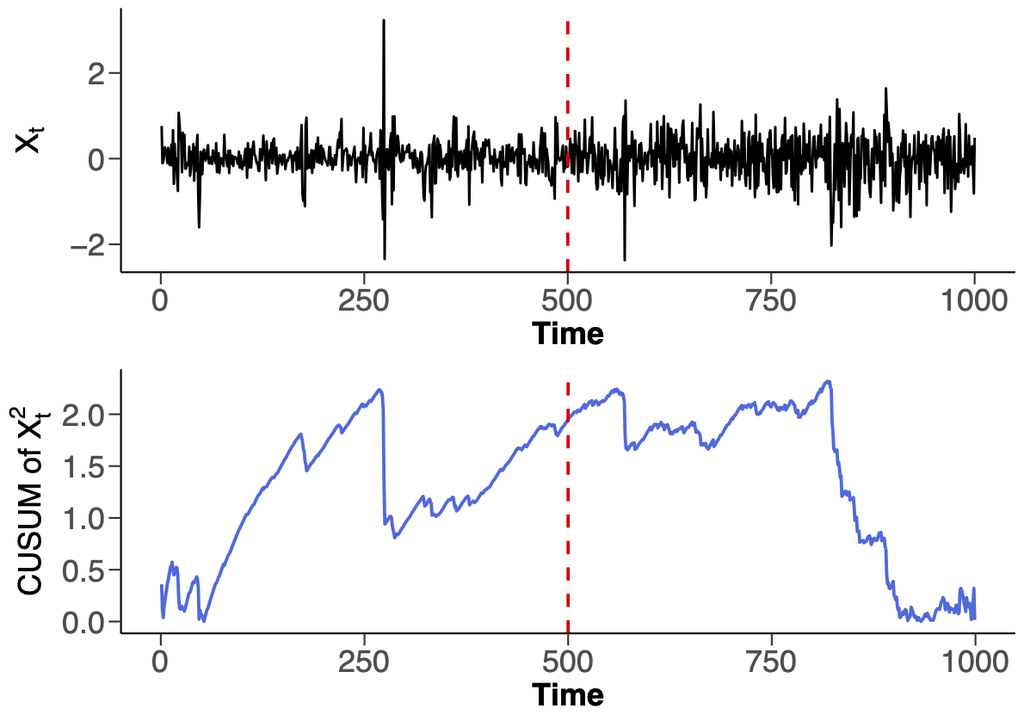

In this case, we can use nonparametric methods.

## Nonparametric approaches

- We can do a kernel version of the least-squares/cost function approach: for given $q$, minimise
  $$L (q) = \frac 1 n \sum_{i=1}^n k(X_i , X_i) - \frac{1}{n} \sum_{j=1}^q \left[ \frac{1}{\theta_j - \theta_{j-1}} \sum_{k = \theta_{j-1}+1}^{\theta_j} \sum_{\ell = \theta_{j-1}+1}^{\theta_j} k(X_k, X_\ell) \right],$$
  where $k(\cdot, \cdot)$ is a kernel function.
- Many choices of kernel: most common is the Gaussian:

$$k(x,y) = \exp ( - || x - y||^2/(2h^2)).$$

- If $k(x,y) = xy$, this becomes the same as the PELT method for changes in mean.
- We are basically just turning the problem into mean change point detection via kernels.

## Nonparametric approaches

Example approach: a single method using one or more test statistics/cost functions can detect multiple types of changes (McGonigle and Cho 2025).

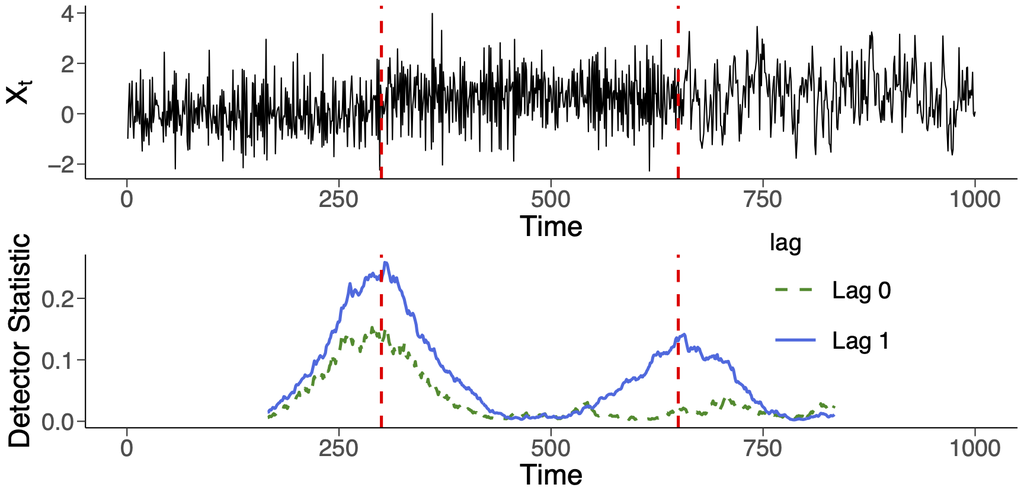

## Model validation/checking assumptions

- Often we want to validate the assumptions of our model, e.g. normality or independence.
- Everything becomes more difficult in the presence of change points:

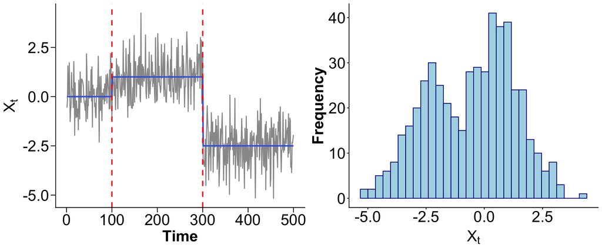

- Can use basic diagnostics like checking residuals, e.g., QQ or ACF plots, with caution.
- We can use model selection approaches to compare competing change point models, e.g., with information criterion.

## Multivariate data

All of the above discussion considered univariate data. What about multivariate data?

- Each variable of the data might be unconnected to the rest: univariate methods could work well.
- There might be structure/dependence across variables. For example,
  1. Changes occur at the same time across all variables,
  2. changes occur only in a subset of variables,
  3. changes in some variables cause changes in others at a later time.
- Many possible other scenarios: different types of change, different noise levels, ...
- Generally, we can take ideas from univariate methods and extend them to multivariate data.

## Multivariate data: combining the evidence

A general strategy: compute a per-coordinate statistic $T_i(k)$ (CUSUM or MOSUM) for each series $i = 1, \ldots, p$, then **aggregate** across coordinates into a single statistic
$$T(k) = f\big(T_1(k), \ldots, T_p(k)\big).$$

- Choices for $f$: sum of squares ($L_2$ aggregation), maximum ($L_\infty$) – see the lab Q5.
- Aggregation pools evidence that is too weak in any one series.

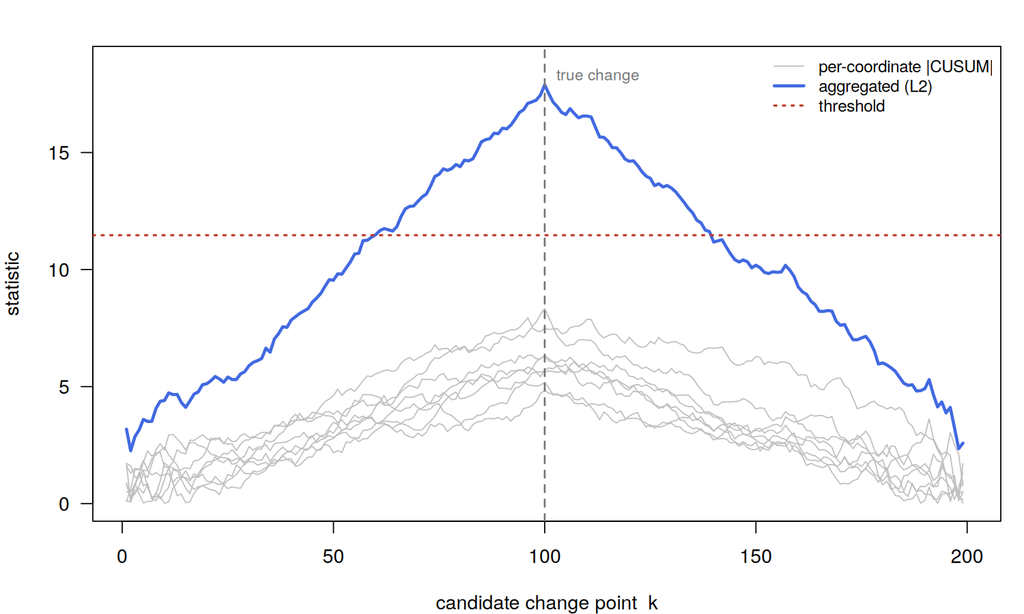

## Multivariate data: dense vs sparse changes

The best way to aggregate depends on **how the change is spread across coordinates**.

- **Dense** (many small shifts): add the evidence up – a sum / $L_2$ aggregation.
- **Sparse** (a few large shifts): $L_2$ dilutes the signal among the null coordinates; use max-type statistics, or **sparse projection** – project onto the best-separating direction, then run a univariate CUSUM (Wang and Samworth 2018).
- How large a change must be to be detectable depends on both $p$ and the sparsity – a *detection boundary*.

## Multivariate data: dense vs sparse changes

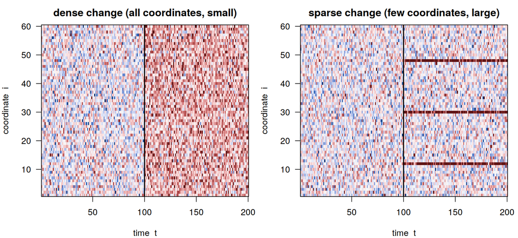

## Multivariate data: the INSPECT method

**INSPECT** (Wang and Samworth 2018) estimates the best *sparse* projection of the high-dimensional CUSUM, then applies a univariate test to the projected series.

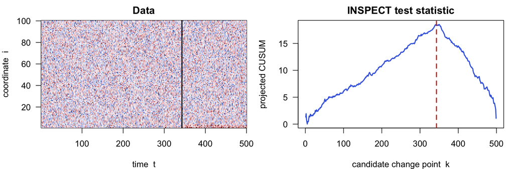

- The sparse change is subtle by eye, but INSPECT can recover it.

## Multivariate data: beyond a change in mean

Again I’ve just covered mean changes, but changes could occur in:

- **Covariance / correlation**: the *relationships* between series shift – e.g. assets that suddenly start moving together.
- **Network / graphical structure**: edges in a dependence graph appear or disappear.
- **Factor structure**: a few common drivers change, moving many series at once.
- **Regression**: using ideas from high-dimensional regression like the LASSO.

Tailored high-dimensional methods exploit sparsity across coordinates, e.g. sparsified binary segmentation (Cho and Fryzlewicz 2015).

## Multivariate data: high-dimensional challenges

- **Dependence across series**: correlated coordinates make thresholds harder to set – ignoring it inflates false alarms.
- **Computation**: cost is naively $O(np)$ or worse; efficient recursive updates and projections matter.
- **Estimation**: how *many* changes, and *where*? Localisation can get harder, not easier, as $p$ grows if the change is sparse.
- **Interpretation**: *which* coordinates drove the change is often the real question of interest.

## Aside: multivariate change point software

Many packages doing multivariate change point detection.

#### In R:

- `ecp`: nonparametric CPD using “energy" distance.
- `InspectChangepoint`: high-dimensional mean CPD using projections.
- `fastcpd`: many settings, including several from `ruptures`.

#### In Python:

- `ruptures`: already has multivariate functionality.
- `gchangepoint`: graph-based nonparametric CPD.
- `changeforest`: nonparametric CPD via random forests.

## Complications/considerations

- **Speed of method**: sequential nature means efficient implementations often possible.
- **High-dimensionality**: how do we aggregate information/find relevant structure?
- **Outliers**: “instantaneous" change points? Many methods not robust.
- **Threshold selection**: how to balance over/under detection?
- **Missing data**: how to impute when there are change points?
- **Autocorrelation**: harder to distinguish changes from noise.

## Aside: some alternative approaches

Whilst I’m contractually obliged to advertise CPD, it’s only 1 of many approaches:

- **Mathematical/physical model**: something that already captures the evolution of behaviour of interest.
- **Local stationarity**: statistical properties evolve slowly.
- **Just ignore it (!)**: for some applications, e.g. forecasting, it might be better to just fit a stationary model.
- **Data pre-processing**: remove nonstationarity first, e.g. via a transformation.

## Modern directions: a plethora of methods

Change point detection is a fast-moving field, pushing well beyond what I’ve covered (Li et al. 2026):

- **Richer detectors** – e.g. neural networks that *learn* the change statistic from data, detectors built on topological features…
- **Richer data types** – networks and other non-Euclidean objects, spatio-temporal fields, high-dimensional tensors, text data…

The segmentation ideas (CUSUM, MOSUM, cost functions) largely carry over.

## Modern directions: neural network detectors

Rather than deriving a test statistic by hand, we can *train* one: a neural network maps a window of the series to a “change score” (Li et al. 2024).

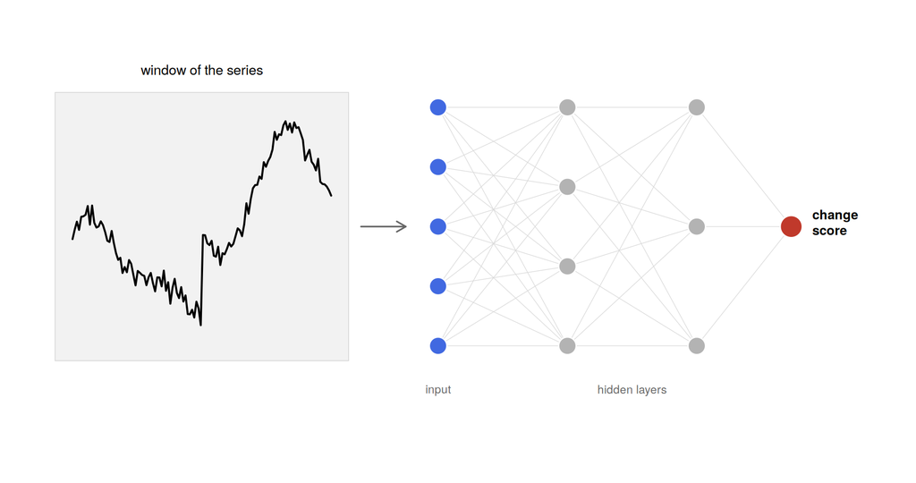

- A CUSUM classifier is a neural net (!) $\to$ method should be at least as good as the CUSUM.
- Learns flexible changes and can be trained on simulated data.
- Trade-off: less interpretable, and needs representative training data.

## Modern directions: non-Euclidean data

The observation at each time need not be a number or a vector – it can be a **network, a shape, or a point on a manifold**. Graph-based tests compare similarity across a candidate split (Chen and Zhang 2015).

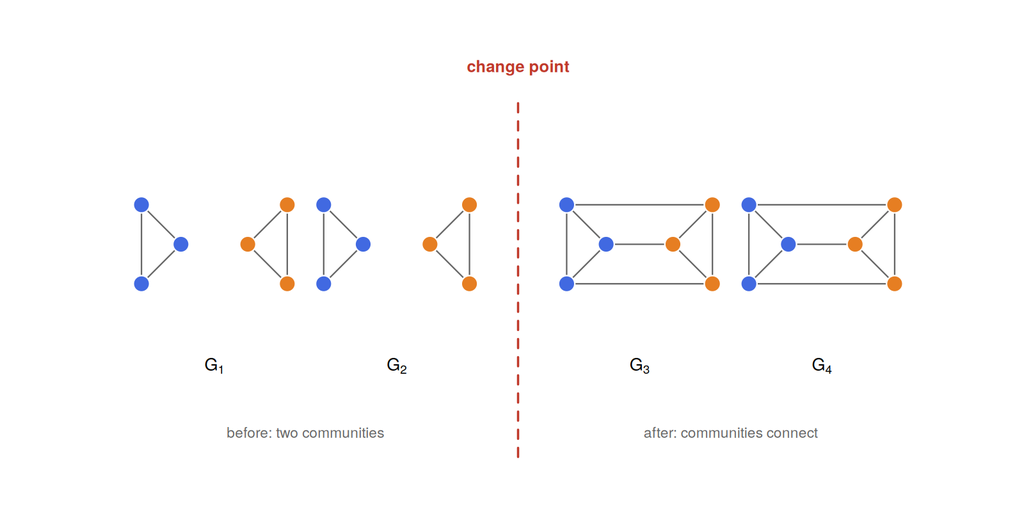

- Applies to graphs, distributions, images – anything with a notion of distance or similarity.
- Idea: build a similarity graph on the observations, then count edges across the split.

## Modern directions: spatio-temporal fields and PDEs

Data indexed over **space and time** – often governed by a physical (PDE/ODE) model – can change *regime*, with the governing dynamics or parameters shifting (Sun et al. 2024).

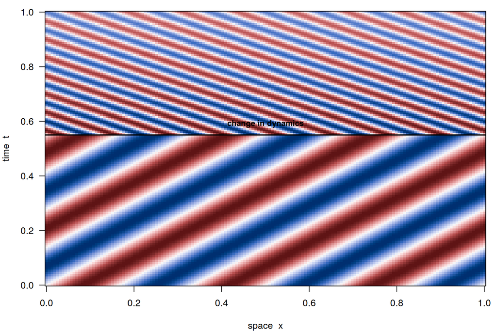

- We detect changes in the *dynamics*, not just the mean level.
- Applications: climate, epidemics (e.g. SEIR models), ecology, fluid dynamics.

## Modern directions: tensors and high dimensions

Stacking a sequence of matrices (dynamic networks, images, …) gives a **3-way tensor**; changes show up in its low-rank or spectral structure (Zhang and Chan 2026).

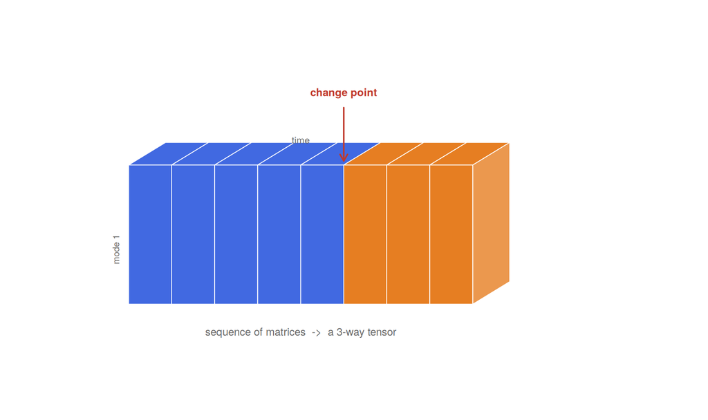

- Exploit low-rank / sparse structure to find changes in very high dimensions.
- Connects to the multivariate aggregation ideas from the lecture and lab.

## Some things to think about

- What types of time series might contain change points?
- What types of change points might you expect to see in the type of data you look at.
- What parameters you might model that have nonstationary behaviour.
- Benefits and drawbacks to a change point approach.
- Homogeneity vs inhomogeneity – over space, time, …

## Further reading

Chen, Hao, and Nancy Zhang. 2015. “Graph-Based Change-Point Detection.” *The Annals of Statistics* 43 (1): 139–76.

Cho, Haeran. 2016. “Change-Point Detection in Panel Data via Double CUSUM Statistic.” *Electronic Journal of Statistics* 10 (2): 2000–2038.

Cho, Haeran, and Piotr Fryzlewicz. 2015. “Multiple-Change-Point Detection for High Dimensional Time Series via Sparsified Binary Segmentation.” *Journal of the Royal Statistical Society Series B: Statistical Methodology* 77 (2): 475–507.

Cho, Haeran, and Claudia Kirch. 2024. “Data Segmentation Algorithms: Univariate Mean Change and Beyond.” *Econometrics and Statistics* 30: 76–95.

Eichinger, Birte, and Claudia Kirch. 2018. “A MOSUM Procedure for the Estimation of Multiple Random Change Points.” *Bernoulli* 24 (1): 526–64.

Enikeeva, Farida, and Zaïd Harchaoui. 2019. “High-Dimensional Change-Point Detection Under Sparse Alternatives.” *The Annals of Statistics* 47 (4): 2051–79.

Fearnhead, Paul, and Piotr Fryzlewicz. 2022. “Detecting a Single Change-Point.” *arXiv Preprint arXiv:2210.07066*.

Fryzlewicz, Piotr. 2014. “Wild Binary Segmentation for Multiple Change-Point Detection.” *The Annals of Statistics* 42 (6): 2243–81.

Killick, Rebecca, and Idris A Eckley. 2014. “Changepoint: An r Package for Changepoint Analysis.” *Journal of Statistical Software* 58: 1–19.

Killick, Rebecca, Paul Fearnhead, and Idris A Eckley. 2012. “Optimal Detection of Changepoints with a Linear Computational Cost.” *Journal of the American Statistical Association* 107 (500): 1590–98.

Li, Jialiang, Jingli Wang, and Yuetao Yu. 2026. “Change-Point Detection and Its Modern Applications.” *Annual Review of Statistics and Its Application* 13: 421–38.

Li, Jie, Paul Fearnhead, Piotr Fryzlewicz, and Tengyao Wang. 2024. “Automatic Change-Point Detection in Time Series via Deep Learning.” *Journal of the Royal Statistical Society Series B: Statistical Methodology* 86 (2): 273–85.

McGonigle, Euan T, and Haeran Cho. 2025. “Nonparametric Data Segmentation in Multivariate Time Series via Joint Characteristic Functions.” *Biometrika* 112 (2): asaf024.

Meier, Alexander, Claudia Kirch, and Haeran Cho. 2021. “Mosum: A Package for Moving Sums in Change Point Analysis.” *Journal of Statistical Software* 97 (8): 1–42.

Sun, Yan, Yeping Wang, Zhaohui Li, and Shihao Yang. 2024. “O-MAGIC: Online Change-Point Detection for Dynamic Systems.” *arXiv Preprint arXiv:2411.12277*.

Truong, Charles, Laurent Oudre, and Nicolas Vayatis. 2018. “Ruptures: Change Point Detection in Python.” *arXiv Preprint arXiv:1801.00826*.

Wang, Tengyao, and Richard J. Samworth. 2018. “High Dimensional Change Point Estimation via Sparse Projection.” *Journal of the Royal Statistical Society Series B: Statistical Methodology* 80 (1): 57–83.

Zhang, Xinyu, and Kung-Sik Chan. 2026. “Spectral Change Point Estimation for High Dimensional Time Series by Sparse Tensor Decomposition.” *Journal of the Royal Statistical Society Series B: Statistical Methodology* 88 (2).